# Aula 3

6 de Janeiro de 2017

## Criando uma tabela para agregarmos

- Vamos criar uma tabela 'pronta' para lidarmos com nossos dados
- Quero uma tabela contendo:
- O código, nome e estado do município
- O valor população, em formato numérico, de homens e mulheres residentes, sendo que a variável descrição diferenciará cada tipo de registro
- Como podemos obter essa consulta?
- pensem nas colunas que queremos
- pensem nas tabelas onde elas estão
- quais os campos chaves entre essas tabelas
- qual o filtro devemos aplicar
- qual o tratamento devemos fazer nos campos

## Tabela para agregação

Passo 1: Determinar quais colunas queremos

```r
select
c.codmun, c.nome
from s3672792.cidades c
```

e

```r
select
s.descricao, s.valor
from s3672792.sintese_informacao s
```

Passo2: Juntando as tabelas

```r
select
c.codmun,c.nome,s.descricao,s.valor
from s3672792.cidades c
left outer join s3672792.sintese_informacao s on (c.codmun = s.codmun)
```

Passo3: Filtrando

```r
select
c.codmun,c.nome,s.descricao, s.valor
from s3672792.cidades c
left outer join s3672792.sintese_informacao s on (c.codmun = s.codmun)
where
descricao like 'População residente - %'
```

Passo4: Tratando os campos:

```r
select
c.codmun,c.nome,s.descricao, s.valor::numeric
from s3672792.cidades c
left outer join s3672792.sintese_informacao s on (c.codmun = s.codmun)
where
descricao like 'População residente - %'
```

- ERROR: invalid input syntax for type numeric: "-"

Passo4: Tratando os campos:

```r
select
c.codmun,c.nome,s.descricao,
case when s.valor = '-' then null
else s.valor::numeric
end as valor
from s3672792.cidades c
left outer join s3672792.sintese_informacao s on (c.codmun = s.codmun)
where
descricao like 'População residente - %'
```

- ERROR: invalid input syntax for type numeric: "1.304.267"

Passo4: Tratando os campos:

```r
select
c.codmun,c.nome
,substr(c.nome,strpos(c.nome,'/')+1) as estado
,s.descricao
,case
when s.valor = '-' then null
else replace(s.valor,'.','')::numeric
end as valor
from s3672792.cidades c
left outer join s3672792.sintese_informacao s on (c.codmun = s.codmun)
where
descricao like 'População residente - %'
```

- OK :D

## Tabela para agregação

- Pronto! Agora é simples, toda vez que precisarmos utilizar esses dados, basta digitarmos somente essas linhas de código!
- Mentira! Para situações de código mais complexo podemos criar uma View
- O que é View?
- Diferença entre View e Tabela
- Quando usar View e quando usar Tabela

## Criando uma view

- Para criarmos a view **vpopulacao**:

```r
create view s3672792.vpopulacao as
select
c.codmun,c.nome
,substr(c.nome,strpos(c.nome,'/')+1) as estado
,s.descricao
,case
when s.valor = '-' then null
else replace(s.valor,'.','')::numeric
end as valor
from s3672792.cidades c
left outer join s3672792.sintese_informacao s on (c.codmun = s.codmun)
where
descricao like 'População residente - %'
```

## Usando a view e voltando ao tema 'Agregação'

- A view é utilizada como se fosse uma tabela:

```r
select * from s3672792.vpopulacao
```

- Voltando a falar em agrupamento
- Quero verificar todos os estados da minha tabela, ou seja, agrupar os dados por estado:

```r
select estado from s3672792.vpopulacao group by estado
```

- Quero fazer uma contagem de quantos registros aparecem por estado:

```r
select  estado, count(*) from s3672792.vpopulacao group by estado
```

## Agregação

- Como faço para saber o número total de residentes em cada estado?
- Basta somar o número de homens e mulheres, agrupado por estado:

```r
select  estado, sum(valor) as total from s3672792.vpopulacao group by estado
```

- E se eu quiser saber o número de homens e mulheres em cada estado?
- Se exibirmos o campo descricao, teremos uma diferenciação dos registros:

```r
select  estado, descricao, sum(valor) from s3672792.vpopulacao
group by estado, descricao
order by estado
```

- Perceba, que temos que adicionar todo campo, não agregado no **group by**

## Outras funções de agregação

- Página do manual do PostgreSQL lista diversas funções de agregação: https://www.postgresql.org/docs/9.5/static/functions-aggregate.html
- Dentre elas, podemos destacar:
- avg: Média aritmética da variável (ignorando valores nulos)
- count: Faz a contagem de registros (ignorando valores nulos)
- min: Valor mínimo da variável (ignorando valores nulos)
- max: Valor máximo da variável (ignorando valores nulos)
- sum: Somatório da variável (ignorando valores nulos)
- corr(X,Y): Coeficiente de correlação entre dois valores
- covar_pop/samp(Y,X): Covariância populacional/amostral
- stddev_pop/samp: Desvio padrão populacional/amostral
- var_pop/samp: Variância populacional/amostral

## Exemplo de funções de agregação

```r
select estado, descricao
,avg(valor)
,count(*)
,min(valor)
,max(valor)
,sum(valor)
,stddev_pop(valor)
,stddev_samp(valor)
,var_pop(valor)
,var_samp(valor)
from s3672792.vpopulacao
group by estado, descricao
```

## Fazendo regressão com SQL

- Cuidado para não fugir do escopo que queremos dar ao SQL
- No SQL preparamos os dados, no R, analisamos os dados
- Vamos montar uma outra view para exemplificarmos:

```r
create view s3672792.vregressao as
select
c.codmun,c.nome,
substr(c.nome,strpos(nome,'/')+1) as estado
,case when spop.valor = '-' then null else replace(spop.valor,'.','')::numeric
end as pop_alfabetizada
,case when smat.valor = '-' then null else replace(smat.valor,'.','')::numeric
end as pop_matriculada_em_2015
from s3672792.cidades c
left outer join s3672792.sintese_informacao spop
on (c.codmun = spop.codmun
    and spop.descricao like 'População residente alfabetizada')
left outer join s3672792.sintese_informacao smat
on (c.codmun = smat.codmun
    and smat.descricao like 'Matrícula - Ensino médio - 2015')
```

## Fazendo regressão com SQL

- O PostgreSQL utiliza o método de MQO para fazer a regressão linear

```r
select estado
,corr(v.pop_matriculada_em_2015,v.pop_alfabetizada)
,covar_pop(v.pop_matriculada_em_2015,v.pop_alfabetizada)
,regr_intercept(v.pop_matriculada_em_2015,v.pop_alfabetizada)
,regr_slope(v.pop_matriculada_em_2015,v.pop_alfabetizada)
,regr_r2(v.pop_matriculada_em_2015,v.pop_alfabetizada)
from s3672792.vregressao v
group by estado
order by estado
```

- O que obtemos com esses resultados?
- Sério! O que obtemos?
- Eu não sei interpretar esses dados direito, ainda (shame on me)

## Outras funções para manipulação de texto

- Algumas funções usadas normalmente para tratar/alterar os dados:
- trim: limpa espaços em branco antes e depois de um texto. Ex: trim(' teste ')=='teste'
- unaccent: remove acentuação de palavras. Ex: unaccent('Ribeirão Preto')=='Ribeirao Preto'
- strtoupper: transforma o texto em maiúsculas. Ex: unaccent(strtoupper('Ribeirão Preto'))=='RIBEIRAO PRETO'
- substr: retorna uma parte de uma string (já usamos)
- strpos: retorna a posição da primeira ocorrência de uma substring dentro de uma string (já usamos)
- Outras funções podem ser encontradas na página: https://www.postgresql.org/docs/9.1/static/functions-string.html

## Continuação Aula 2

## Eliminando registros em duplicidade (e matando outros coelhos)

```r
create table s3672792.sintese_informacao_new as
select distinct * from s3672792.sintese_informacao;

delete from  s3672792.sintese_informacao;

insert into s3672792.sintese_informacao
select * from s3672792.sintese_informacao_new;

drop table s3672792.sintese_informacao_new;
```

## Criando tabelas a partir de consultas

- Quando trabalhamos com dados podemos ter 2 situações:
  - Os dados são fixos e coletados uma única vez
  - Os dados são dinâmicos e coletados periodicamente
- Quando os dados são fixos, vale a pena alterar a ESTRUTURA da tabela
- Quando os dados são dinâmicos, a melhor opção é criar uma tabela intermediária, com os dados tratados

## Alterando a tabela de cidades

- Na nossa tabela de cidades, faz sentido criarmos o campo **estado** e apagarmos o campo **row.names**
- Vimos que o campo **estado** foi utilizado em diversas consultas anteriores, portanto é um bom candidato a criação
- Temos o campo codmun que pode ser nossa **chave primária** (explicar melhor), portanto, não precisamos do campo **row.names**
- Vamos realizar essas tarefas com o código:

```r
ALTER TABLE s3672792.cidades DROP COLUMN "row.names"; /*apagando a coluna row.names*/
ALTER TABLE s3672792.cidades ADD COLUMN estado CHAR(2); /*criando a coluna estado*/
UPDATE s3672792.cidades SET estado = substr(nome,strpos(nome,'/')+1) /*atualizando a coluna estado*/
```

## Criando tabelas intermediárias

- Quando trabalharmos com tabelas que obtemos de outras fontes é melhor criar tabelas intermediárias
- Vamos refazer nossa view vregressao e criar uma tabela para deixar os dados pré-processados

```r
drop table  s3672792.cidade_sintese;
create table s3672792.cidade_sintese as
select distinct c.codmun,c.nome, c.estado
,case when spop.valor = '-' then null else replace(spop.valor,'.','')::numeric end as pop_alfabetizada
,case when smat.valor = '-' then null else replace(smat.valor,'.','')::numeric end as pop_matriculada_em_2015
,case when spoph.valor = '-' then null else replace(spoph.valor,'.','')::numeric end as pop_homens
,case when spopm.valor = '-' then null else replace(spopm.valor,'.','')::numeric end as pop_mulheres
,case when sus.valor = '-' then null else replace(sus.valor,'.','')::numeric end as nro_estab_sus
from s3672792.cidades c left outer join s3672792.sintese_informacao spop
on (c.codmun = spop.codmun and spop.descricao = 'População residente alfabetizada')
left outer join s3672792.sintese_informacao smat
on (c.codmun = smat.codmun and smat.descricao = 'Matrícula - Ensino médio - 2015')
left outer join s3672792.sintese_informacao spoph
on (c.codmun = spoph.codmun and spoph.descricao = 'População residente - Homens')
left outer join s3672792.sintese_informacao spopm
on (c.codmun = spopm.codmun and spopm.descricao = 'População residente - Mulheres')
left outer join s3672792.sintese_informacao sus
on (c.codmun = sus.codmun and sus.descricao = 'Estabelecimentos de Saúde SUS')
```

## Diferenças entre View e Tabelas

- Velocidade
  - select * from vregressao: 82ms
  - select * from cidade_sintese: 7ms
- Periodicidade de mudança dos dados

## O que o SQL não faz (tão bem)

- Pivoteamento
- Lidar com observações que estão abaixo ou acima
- Dados não estruturados
- Tratamento de dados em várias etapas (sub-queries)

## Sub-queries

- Com SQL temos que ter cuidado com a ordem de execução da consulta
- A consulta é analisada de 'dentro para fora'.Ex:

```r
select *
  , c.pop_mulheres+c.pop_homens as pop_total
, c.pop_alfabetizada/pop_total
from s3672792.cidade_sintese c
```

- Deu erro! Porque?
- Perceba que o erro é: pop_total não existe
- A variável só é efetivamente criada APÓS a execução da consulta
- Como proceder?

## Sub-queries

- Nessas situações devemos fazer nossas consultas em 2 etapas
- Pensem nisso:
- O que o comando **select** espera após o from?
- O que o comando **select** retorna?
- O que nos impede de passar o retorno de um **select** como tabela de outro **select**?

```r
select *, t1.pop_alfabetizada/pop_total from (
  select *
    , c.pop_mulheres+c.pop_homens as pop_total
  from s3672792.cidade_sintese c
) as t1
```

- Você pode aninhar quantos níveis quiser, só lembrando de nomear cada um

## Análise de dados - Aula 3

## Obtendo os dados

- Vamos trabalhar com a nossa tabela cidade_sintese
- Primeiramente, importamos ela para o R

```r
conCurso <<- dbConnect(PostgreSQL(), user= "r_workflow", password="curso",  dbname="r_workflow",host="143.107.205.218",port='5432')
sSql <- "select * from s3672792.cidade_sintese"
res <- dbSendQuery(conCurso, sSql)
dCidade <- fetch(res,n=-1)
```

## Produzindo estatísticas descritivas

- Podemos verificar os dados de um dataframe com a função summary

```r
summary(dCidade[,1:4])
```

```
##      codmun           nome              estado          pop_alfabetizada
##  Min.   :110001   Length:5570        Length:5570        Min.   :     676
##  1st Qu.:251212   Class :character   Class :character   1st Qu.:    3991
##  Median :314628   Mode  :character   Mode  :character   Median :    8310
##  Mean   :325359                                         Mean   :   28325
##  3rd Qu.:411919                                         3rd Qu.:   17533
##  Max.   :530010                                         Max.   :10033341
##                                                         NA's   :5
```

## Produzindo estatísticas descritivas

- Podemos obter maiores detalhes com o pacote psych

```r
library(psych)
describe(dCidade)
```

```
##                         vars    n      mean        sd   median   trimmed
## codmun                     1 5570 325358.63  98491.03 314627.5 324068.40
## nome*                      2 5570       NaN        NA       NA       NaN
## estado*                    3 5570       NaN        NA       NA       NaN
## pop_alfabetizada           4 5565  28325.03 180699.32   8310.0  11130.01
## pop_matriculada_em_2015    5 5570   1449.71   8705.03    413.0    593.38
## pop_homens                 6 5565  16784.72  96103.72   5548.0   7389.48
## pop_mulheres               7 5565  17493.05 107022.44   5419.0   7287.60
## nro_estab_sus              8 5565     11.35     21.14      6.0      7.74
##                               mad    min      max    range  skew kurtosis
## codmun                  109938.50 110001   530010   420009  0.12    -0.53
## nome*                          NA    Inf     -Inf     -Inf    NA       NA
## estado*                        NA    Inf     -Inf     -Inf    NA       NA
## pop_alfabetizada          7645.77    676 10033341 10032665 38.08  1881.32
## pop_matriculada_em_2015    394.37      0   505612   505612 39.86  2112.51
## pop_homens                5163.90    422  5328632  5328210 37.56  1852.73
## pop_mulheres              5061.60    383  5924871  5924488 37.77  1857.29
## nro_estab_sus                5.93      0      678      678 11.67   246.28
##                              se
## codmun                  1319.68
## nome*                        NA
## estado*                      NA
## pop_alfabetizada        2422.28
## pop_matriculada_em_2015  116.64
## pop_homens              1288.27
## pop_mulheres            1434.64
## nro_estab_sus              0.28
```

## Produzindo estatísticas descritivas

- Podemos refinar nossa pesquisa agrupando variáveis de interesse

```r
dTemp <- subset(dCidade[dCidade$estado %in% c('SP','RJ'),])
describeBy(dTemp[,c('estado','pop_alfabetizada')],group=dTemp$estado)
```

```
## $RJ
##                  vars  n     mean       sd  median  trimmed      mad  min
## estado*             1 92      NaN       NA      NA      NaN       NA  Inf
## pop_alfabetizada    2 92 154116.3 606387.1 29743.5 55999.73 29340.65 4449
##                      max   range skew kurtosis       se
## estado*             -Inf    -Inf   NA       NA       NA
## pop_alfabetizada 5707871 5703422 8.38    73.53 63220.22
##
## $SP
##                  vars   n     mean       sd median  trimmed   mad min
## estado*             1 645      NaN       NA     NA      NaN    NA Inf
## pop_alfabetizada    2 645 56463.69 405032.8  10829 19260.08 11588 676
##                       max    range  skew kurtosis       se
## estado*              -Inf     -Inf    NA       NA       NA
## pop_alfabetizada 10033341 10032665 23.24    567.9 15948.15
##
## attr(,"call")
## by.data.frame(data = x, INDICES = group, FUN = describe, type = type)
```

## Funções estatísticas

- Também podemos utilizar as funções:
- mean
- sd
- median
- min
- max
- range
- skew: viés

## Reshape

```r
  sSql <- "select * from s3672792.sintese_informacao"
  res <- dbSendQuery(conCurso, sSql)
  dSintese <- fetch(res,n=-1)
  dLargo <- reshape(dSintese[c('codmun','ano','descricao','valor')]
                  , timevar='descricao',idvar=c('codmun','ano')
                  ,direction = 'wide'
                  )
  #warnings()
```

## Regressão

- A regressão é uma ferramenta bastante utilizada para predição do comportamento das variáveis
- A mais comumente utilizada é a regressão linear
- Vejamos o comportamento do Nro de estabelecimentos do SUS em relação à população alfabetizada

```r
r1 <- lm(dCidade$nro_estab_sus ~ dCidade$pop_alfabetizada)
r1
```

```
##
## Call:
## lm(formula = dCidade$nro_estab_sus ~ dCidade$pop_alfabetizada)
##
## Coefficients:
##              (Intercept)  dCidade$pop_alfabetizada
##                8.796e+00                 9.031e-05
```

## Regressão

```r
summary(r1)
```

```
##
## Call:
## lm(formula = dCidade$nro_estab_sus ~ dCidade$pop_alfabetizada)
##
## Residuals:
##      Min       1Q   Median       3Q      Max
## -267.246   -6.107   -3.306    1.619  216.220
##
## Coefficients:
##                           Estimate Std. Error t value Pr(>|t|)
## (Intercept)              8.796e+00  1.824e-01   48.23   <2e-16 ***
## dCidade$pop_alfabetizada 9.031e-05  9.971e-07   90.57   <2e-16 ***
## ---
## Signif. codes:  0 '***' 0.001 '**' 0.01 '*' 0.05 '.' 0.1 ' ' 1
##
## Residual standard error: 13.44 on 5563 degrees of freedom
##   (5 observations deleted due to missingness)
## Multiple R-squared:  0.5959, Adjusted R-squared:  0.5958
## F-statistic:  8203 on 1 and 5563 DF,  p-value: < 2.2e-16
```

## Regressão

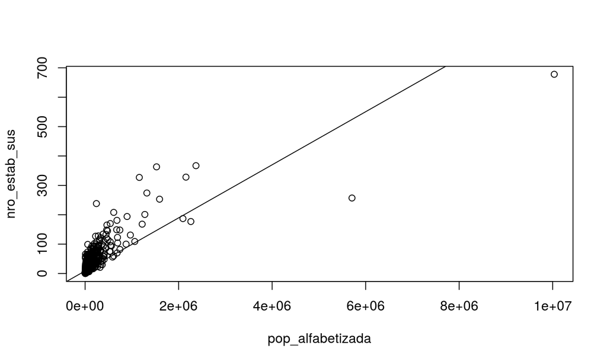

```r
plot(nro_estab_sus ~ pop_alfabetizada,data=dCidade)
abline(r1)
```

## Regressão

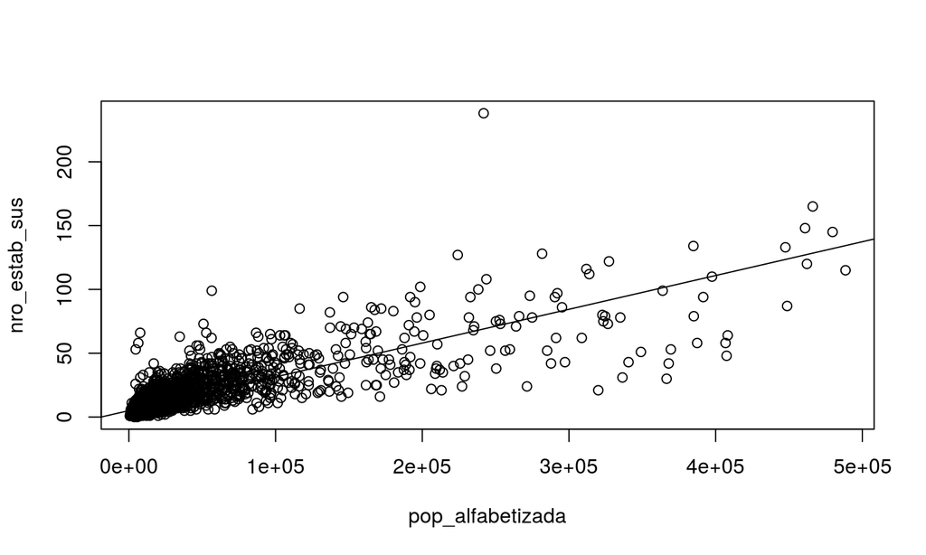

```r
dTemp <- dCidade[dCidade$pop_alfabetizada<500000,]
plot(nro_estab_sus ~ pop_alfabetizada,data=dTemp)
abline(lm(dTemp$nro_estab_sus ~dTemp$pop_alfabetizada))
```

## Regressão

- Podemos também fazer uma regressão com mais de uma variável explicativa

```r
r2 <- lm(dTemp$nro_estab_sus ~dTemp$pop_alfabetizada+dTemp$pop_homens+dTemp$pop_mulheres)
summary(r2)
```

```
##
## Call:
## lm(formula = dTemp$nro_estab_sus ~ dTemp$pop_alfabetizada + dTemp$pop_homens +
##     dTemp$pop_mulheres)
##
## Residuals:
##     Min      1Q  Median      3Q     Max
## -67.605  -2.947  -1.218   1.693 147.473
##
## Coefficients:
##                          Estimate Std. Error t value Pr(>|t|)
## (Intercept)             3.870e+00  1.226e-01  31.579  < 2e-16 ***
## dTemp$pop_alfabetizada -6.480e-04  3.211e-05 -20.180  < 2e-16 ***
## dTemp$pop_homens        3.406e-04  8.571e-05   3.973 7.18e-05 ***
## dTemp$pop_mulheres      1.214e-03  9.425e-05  12.881  < 2e-16 ***
## ---
## Signif. codes:  0 '***' 0.001 '**' 0.01 '*' 0.05 '.' 0.1 ' ' 1
##
## Residual standard error: 7.193 on 5529 degrees of freedom
##   (5 observations deleted due to missingness)
## Multiple R-squared:  0.7193, Adjusted R-squared:  0.7192
## F-statistic:  4723 on 3 and 5529 DF,  p-value: < 2.2e-16
```

## Regressão

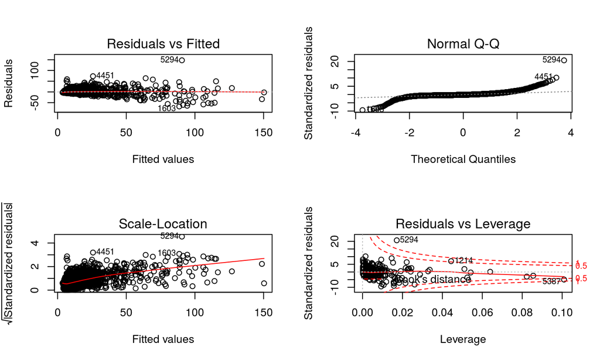

```r
par(mfrow = c(2, 2))
plot(r2)
```

## Regressão Logit

- Para a regressão Logit, precisamos ter uma variável categórica ou binária
- Para nosso exemplo, vamos criar uma variável que será 1 se a cidade tiver mais de 80% da população alfabetizada, 0 caso contrário

```r
dCidade$mais_de_80perc <- 0
dCidade$mais_de_80perc[dCidade$pop_alfabetizada/(dCidade$pop_homens+dCidade$pop_mulheres) > 0.8] <- 1
```

## Regressão Logit

- Agora, vamos analisar o comportamento desta variável em relação ao número de estabelecimentos do SUS

```r
g1 <- glm(mais_de_80perc ~ nro_estab_sus, data=dCidade, family = "binomial")
summary(g1)
```

```
##
## Call:
## glm(formula = mais_de_80perc ~ nro_estab_sus, family = "binomial",
##     data = dCidade)
##
## Deviance Residuals:
##     Min       1Q   Median       3Q      Max
## -2.2239  -1.1865   0.9337   1.1727   1.1988
##
## Coefficients:
##                Estimate Std. Error z value Pr(>|z|)
## (Intercept)   -0.050225   0.033050  -1.520    0.129
## nro_estab_sus  0.010230   0.001837   5.568 2.58e-08 ***
## ---
## Signif. codes:  0 '***' 0.001 '**' 0.01 '*' 0.05 '.' 0.1 ' ' 1
##
## (Dispersion parameter for binomial family taken to be 1)
##
##     Null deviance: 7709.5  on 5564  degrees of freedom
## Residual deviance: 7669.5  on 5563  degrees of freedom
##   (5 observations deleted due to missingness)
## AIC: 7673.5
##
## Number of Fisher Scoring iterations: 4
```

## Regressão Logit

- Plotando o resultado

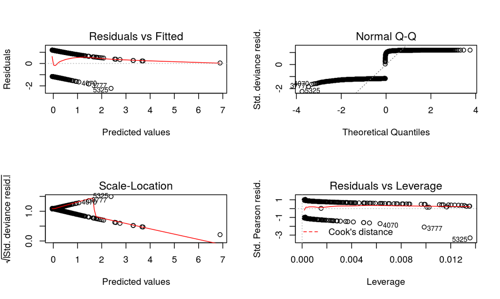

```r
par(mfrow = c(2, 2))
plot(g1)
```

## Análise das regressões

- Intervalo de confiança

```r
confint(g1)
```

```
##                     2.5 %     97.5 %
## (Intercept)   -0.11529688 0.01425968
## nro_estab_sus  0.00675684 0.01395310
```

```r
confint(r2)
```

```
##                                2.5 %        97.5 %
## (Intercept)             3.6302146116  4.1107738938
## dTemp$pop_alfabetizada -0.0007109414 -0.0005850442
## dTemp$pop_homens        0.0001725255  0.0005085732
## dTemp$pop_mulheres      0.0010292719  0.0013988063
```

## Análise das regressões

- Coeficientes

```r
coefficients(r2)
```

```
##            (Intercept) dTemp$pop_alfabetizada       dTemp$pop_homens
##           3.8704942527          -0.0006479928           0.0003405494
##     dTemp$pop_mulheres
##           0.0012140391
```

```r
head(residuals(r2))
```

```
##         1         2         3         4         5         6
##  2.407386 -4.890589 -3.299452 -4.453643  2.059765 -2.571702
```

## Análise das regressões

- teste t

```r
t.test(dCidade$nro_estab_sus,dCidade$pop_alfabetizada)
```

```
##
##  Welch Two Sample t-test
##
## data:  dCidade$nro_estab_sus and dCidade$pop_alfabetizada
## t = -11.689, df = 5564, p-value < 2.2e-16
## alternative hypothesis: true difference in means is not equal to 0
## 95 percent confidence interval:
##  -33062.29 -23565.07
## sample estimates:
##   mean of x   mean of y
##    11.35382 28325.03073
```

## Análise das regressões

- Prevendo o valor do número de estabelecimentos do SUS, de acordo com a população alfabetizada

```r
r1 <- lm(nro_estab_sus ~ pop_alfabetizada, data=dCidade)
dPopAlfabetizada <- data.frame(pop_alfabetizada=100000)
#dCidade$estimativa <-
predict(r1,dPopAlfabetizada, interval="predict")
```

```
##        fit       lwr     upr
## 1 17.82644 -8.522618 44.1755
```

## Análise das regressões

- teste ANOVA

```r
anova(r2, test="Chisq")
```

```
## Analysis of Variance Table
##
## Response: dTemp$nro_estab_sus
##                          Df Sum Sq Mean Sq  F value    Pr(>F)
## dTemp$pop_alfabetizada    1 690878  690878 13351.69 < 2.2e-16 ***
## dTemp$pop_homens          1  33712   33712   651.51 < 2.2e-16 ***
## dTemp$pop_mulheres        1   8586    8586   165.92 < 2.2e-16 ***
## Residuals              5529 286096      52
## ---
## Signif. codes:  0 '***' 0.001 '**' 0.01 '*' 0.05 '.' 0.1 ' ' 1
```

## Análise com particionamentos (clusters)

- Podemos agrupar nossos dados com a utilização do método k-means

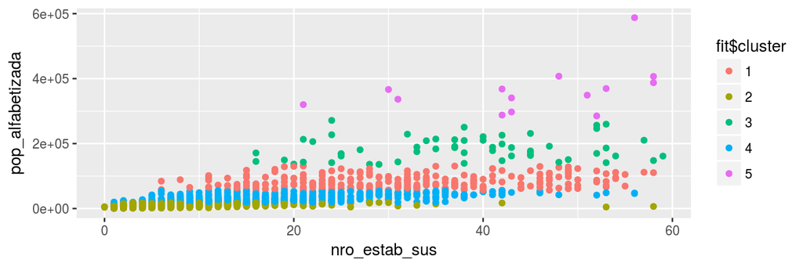

```r
dTemp <- na.omit(dCidade)
dTemp <- dTemp[dTemp$nro_estab_sus < 60,]
fit <- kmeans(dTemp[,c('nro_estab_sus','pop_alfabetizada')], 5)
fit$cluster <- as.factor(fit$cluster)
ggplot(dTemp,aes(x=nro_estab_sus,y=pop_alfabetizada,color=fit$cluster))+
  geom_point()
```

## Gráficos

## O pacote ggplot2

- O pacote ggplot (e agora sua versão mais nova ggplot2) vem se consolidando como um dos pacotes mais usados para geração de gráficos
- Bastante flexível
- Poderoso
- Muito personalizável
- Bonito!
- Coisas que não deveriam ser feitas com ggplot:
- Gráficos 3D (pacote rgl)
- Grafos (pacote igraph)
- Gáficos interativos (pacote ggvis e shiny)

## A gramática dos gráficos

- Para criarmos gráficos criamos **blocos** de sintaxe e juntamos
- Vamos brincar de lego?
- Quais são os blocos com os quais podemos trabalhar:
- Dados
- Mapeamento estético
- Objetos geométricos
- Transformações estatíticas
- Escalas
- Sistema de coordenadas
- Ajustes de posição
- O curso será focado 'apenas' em Dados e Mapeamento estético

## Histograma

- Podemos plotar facilmente um histograma em R com a função hist()

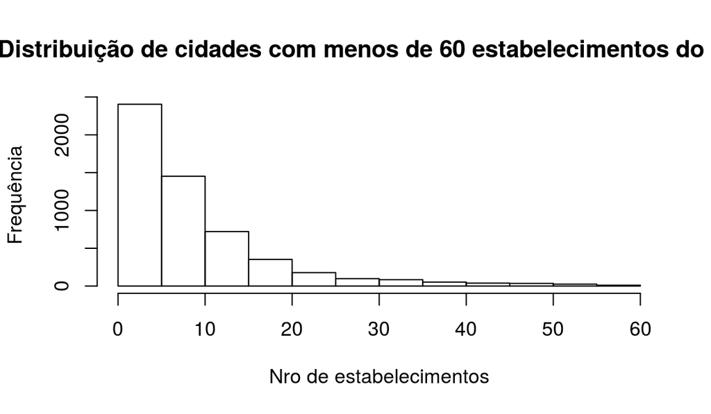

```r
hist(dCidade[dCidade$nro_estab_sus < 60,c('nro_estab_sus')],
     main = 'Distribuição de cidades com menos de 60 estabelecimentos do SUS'
     ,xlab = 'Nro de estabelecimentos', ylab='Frequência'
)
```

## Histograma

- Com ggplot2

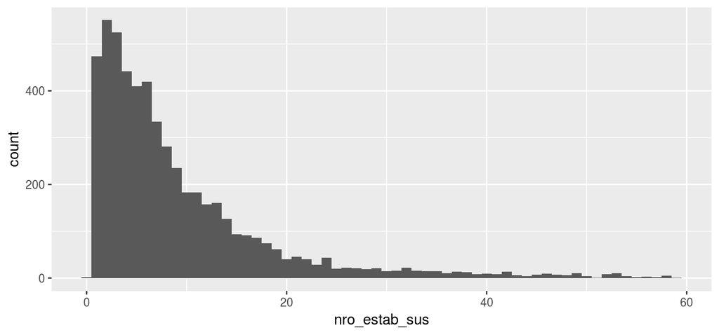

```r
library(ggplot2)
ggplot(data=subset(dCidade,nro_estab_sus<60), aes(x = nro_estab_sus)) +
  geom_histogram(binwidth=1)
```

## Gráfico de barras

- Como seria um gráfico de barras mostrando a distribuição entre homens e mulheres em cada estado?
- Para isso, vamos montar uma nova consulta

```r
sSql <- "select c.estado, s.descricao,
sum(case when valor = '-' then 0 else replace(valor,'.','')::numeric end) as valor
from s3672792.cidades c
inner join s3672792.sintese_informacao  s on (c.codmun = s.codmun)
where
s.descricao = 'População residente - Mulheres'
or
s.descricao = 'População residente - Homens'
group by estado,descricao"
res <- dbSendQuery(conCurso, sSql)
dBarra <- fetch(res,n=-1)
```

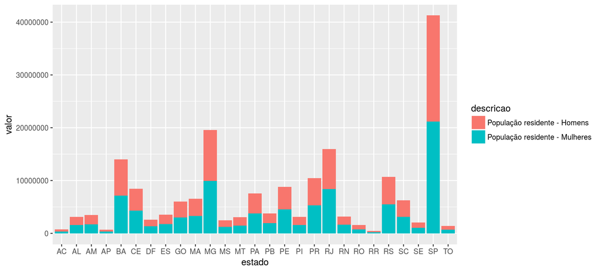

```r
options(scipen=999)
ggplot(data=dBarra) +
  geom_bar(aes(x = estado,y=valor, fill=descricao),stat = "identity")
```

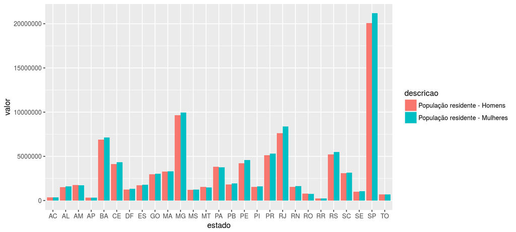

```r
ggplot(data=dBarra) +
  geom_bar(aes(x = estado,y=valor, fill=descricao),stat = "identity",position = 'dodge')
```

## Scatterplot

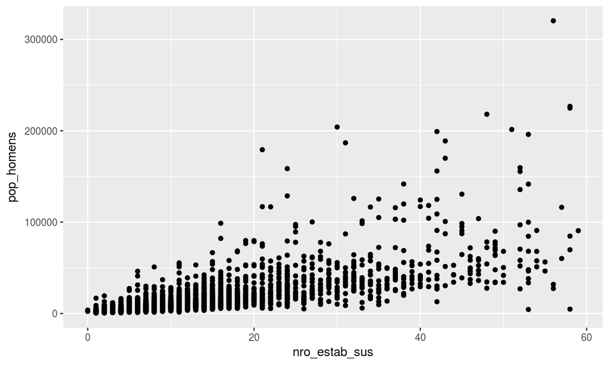

```r
ggplot(data=subset(dCidade,nro_estab_sus<60), aes(x = nro_estab_sus, y = pop_homens)) +
  geom_point()
```

## Scatterplot

- Vamos adicionar a série de população de mulheres, bem como colocar uma curva de regressão
- Mais algumas poucas alterações….

```r
plot <- ggplot(data=subset(dCidade,nro_estab_sus<60)) +
  geom_point(aes(x = nro_estab_sus, y = log(pop_homens),color='homem'),shape=3)+
  geom_point(aes(x = nro_estab_sus, y = log(pop_mulheres),color='mulher'),shape=1)+
  geom_smooth(aes(x = nro_estab_sus, y = log(pop_homens))
              ,method = 'lm',col='darkblue')+
  geom_smooth( aes(x = nro_estab_sus, y = log(pop_mulheres))
               ,method='loess',col='magenta'
  )+
  labs(title='Estabelecimentos SUS x População',x='Nro estabelecimentos SUS',y='log(População)')+
  scale_colour_manual(name = 'Gênero',
                      values =c('homem'='blue','mulher'='tomato1'), labels = c('Homem','Mulher'))
```

- Obtemos o gráfico abaixo

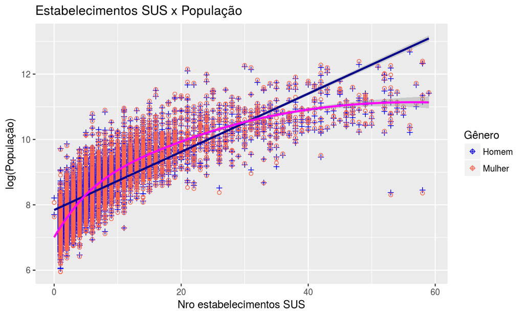

## Gráfico de linhas

- O gráfico de linhas é bem simples

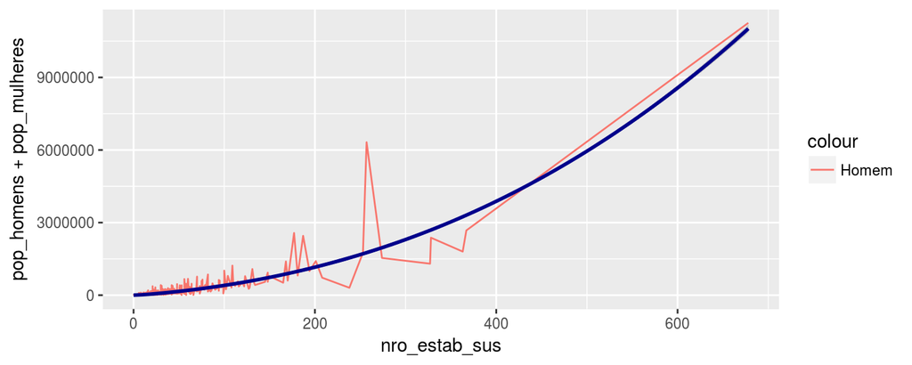

```r
ggplot(data=dCidade) +
  geom_line(aes(x = nro_estab_sus, y = pop_homens+pop_mulheres,color='Homem'))+
  geom_smooth(aes(x = nro_estab_sus, y = pop_homens+pop_mulheres)
              ,method = 'loess',col='darkblue')
```

## Gráfico de pizza

- Um gráfico de pizza com ggplot nada mais é que um gráfico de barras, com rotação polar em y

```r
df <- data.frame(
  variable = c("não se parece", "parece"),
  value = c(20, 80)
)
pac <- ggplot(df, aes(x = "", y = value, fill = variable)) +
  geom_bar(width = 1, stat = "identity") +
  scale_fill_manual(values = c("red", "yellow")) +
  coord_polar("y", start = pi / 2) +
  labs(title = "Pac man")
```

## Gráfico de pizza

[figure not shown]

```r
pac
```

## Correlograma

- Podemos gerar facilmente um correlograma das variáveias com:

[figure not shown]

```r
library(corrgram)
corrgram(dCidade, lower.panel=panel.ellipse)
```

## Plotando mapas com o leafLet

- O pacote leafLet foir criado pelos mesmos programadores do RStudio
- Bastante flexível
- Poderoso
- SIMPLES de usar
- Vamos plotar a localização de todos os shoppings do Brasil
- Pelo menos, aqueles que pegamos as coordenadas
- A documentação pode ser encontrada nos sites:
- http://leafletjs.com/
- https://rstudio.github.io/leaflet/

## Plotando mapas com o leaflet

```r
library(leaflet)
sSql <- "select * from s3672792.shoppings where lat != ''"
res <- dbSendQuery(conCurso, sSql)
dShoppings <- fetch(res,n=-1)
m <- leaflet(dShoppings) %>% addTiles()
m <- m %>% setView(lng = -48.021152, lat = -15.797552, zoom = 4) %>%  addProviderTiles("Esri.WorldStreetMap")
```

## Plotando mapas com o leaflet

```r
m
```

[interactive chart not shown]

## Plotando mapas com o leaflet

- no site https://leaflet-extras.github.io/leaflet-providers/preview/ encontramos exemplos de Tiles Providers

```r
leaflet(dShoppings) %>% addTiles() %>%
  setView(lng = -48.021152, lat = -15.797552, zoom = 4) %>% addProviderTiles("Esri.NatGeoWorldMap")
```

[interactive chart not shown]

## Adicionando marcadores

```r
dShoppings$lat <- as.numeric(dShoppings$lat)
dShoppings$lng <- as.numeric(dShoppings$lng)
m <- leaflet(dShoppings) %>% addTiles() %>%
  setView(lng = -48.021152, lat = -15.797552, zoom = 4) %>%
  addProviderTiles("Esri.WorldStreetMap") %>%
  addMarkers(lng = dShoppings$lng,lat=dShoppings$lat)
```

## Adicionando marcadores

```r
m
```

[interactive chart not shown]

## Alterando os marcadores

- Colocando o popup da administradora do shopping

```r
library(htmltools)
m <- m %>% clearControls() %>%
  clearMarkerClusters() %>%
  addMarkers(lng = dShoppings$lng,lat=dShoppings$lat,popup = ~htmlEscape(dShoppings$administradora))
m
```

[interactive chart not shown]

## Alterando os marcadores

- Agrupando

```r
m %>% clearMarkers() %>%
  addMarkers(lng = dShoppings$lng,lat=dShoppings$lat
             ,popup = ~htmlEscape(dShoppings$administradora)
             ,clusterOptions = markerClusterOptions())
```

[interactive chart not shown]